# Assignment 2 for 297.101 Statistical Data Science

Author

savnit prasad (26019118)

Published

September 26, 2026

## Question 1: Faulty Aircraft Components

**(a) Construct the full table needed for calculating probabilities, including all row and column totals.**

Of the 246 components made in New Zealand, 195 passed the test, so 246 − 195 = 51 were faulty. Of the 201 components made off-shore, 121 passed the test, so 201 − 121 = 80 were faulty.

```r
NZ_total = 246
NZ_passed = 195
OS_total = 201
OS_passed = 121

components = data.frame(
  Passed = c(NZ_passed, OS_passed, NZ_passed + OS_passed),
  Faulty = c(NZ_total - NZ_passed, OS_total - OS_passed,
             (NZ_total - NZ_passed) + (OS_total - OS_passed)),
  Total = c(NZ_total, OS_total, NZ_total + OS_total),
  row.names = c("New Zealand", "Overseas", "Total")
)
components
```

```
            Passed Faulty Total
New Zealand    195     51   246
Overseas       121     80   201
Total          316    131   447
```

**(b) What is the probability that a randomly selected component is faulty and was made overseas?**

This is a joint probability: the component must be faulty **and** made overseas, out of all 447 components tested.

```r
OS_faulty = OS_total - OS_passed
Grand_total = NZ_total + OS_total
round(OS_faulty / Grand_total, 4)
```

```
[1] 0.179
```

**P(faulty and overseas) = 80/447 ≈ 0.179.**

**(c) If a randomly selected component is found to be faulty, what is the probability it was made in New Zealand?**

This is a conditional probability: we already know the component is faulty, so we only consider the 131 faulty components, of which 51 were made in New Zealand.

```r
NZ_faulty = NZ_total - NZ_passed
round(NZ_faulty / (NZ_faulty + OS_faulty), 4)
```

```
[1] 0.3893
```

**P(New Zealand | faulty) = 51/131 ≈ 0.389.**

**(d) If a randomly selected component is found to be from the New Zealand factory, what is the probability that it was faulty?**

Now the condition is the factory, so we only consider the 246 NZ components, of which 51 were faulty.

```r
round(NZ_faulty / NZ_total, 4)
```

```
[1] 0.2073
```

**P(faulty | New Zealand) = 51/246 ≈ 0.207.**

**(e) If you could assume the probability that a component was faulty was independent of the probability that it was made in New Zealand, what would the probability be of a randomly selected component being a faulty component produced overseas?**

If being faulty was independent of where it was made, the joint probability would be the product of the two marginal probabilities:

```r
P_faulty = (NZ_faulty + OS_faulty) / Grand_total
P_overseas = OS_total / Grand_total
round(P_faulty * P_overseas, 4)
```

```
[1] 0.1318
```

**P(faulty and overseas) = P(faulty) × P(overseas) = (131/447) × (201/447) ≈ 0.132.**

**(f) Justify why you believe the fault rate of parts is or is not independent of where they were manufactured.**

```r
round(NZ_faulty / NZ_total, 4)      # P(faulty | made in NZ)
```

```
[1] 0.2073
```

```r
round(OS_faulty / OS_total, 4)      # P(faulty | made overseas)
```

```
[1] 0.398
```

```r
round(OS_faulty / Grand_total, 4)   # actual joint P(faulty and overseas)
```

```
[1] 0.179
```

```r
round(P_faulty * P_overseas, 4)     # joint probability if independent
```

```
[1] 0.1318
```

The fault rate is **not** independent of where the component was manufactured. If the two were independent, the probability of a fault would be the same for both factories, but P(faulty | overseas) ≈ 0.398 is nearly double P(faulty | New Zealand) ≈ 0.207. Equivalently, the actual joint probability P(faulty and overseas) ≈ 0.179 is not equal to the independence value P(faulty) × P(overseas) ≈ 0.132. Because knowing where a component was made changes the probability that it is faulty, the two events are dependent.

## Question 2: Space Telescope Reliability

The probability that a single mirror is still fully functional after $t$ years is $R(t) = \exp\left(-(t/8.7)^{3.9}\right)$. The three mirrors are assumed to fail independently of one another.

**(a) All mirrors must be working to take the most detailed photographs. What is the probability that the telescope can produce these types of pictures for at least 5 years?**

All three mirrors must still be working after 5 years, so the system survives only if every mirror survives (a “series” system). By independence, P(all 3 survive) = R(5) × R(5) × R(5) = R(5)³.

```r
R5 = exp(-(5 / 8.7)^3.9)
R5
```

```
[1] 0.891092
```

```r
round(R5^3, 4)
```

```
[1] 0.7076
```

R(5) ≈ 0.8911, so the probability of taking the most detailed photographs for at least 5 years is 0.8911³ ≈ **0.708**.

**(b) The lowest resolution photographs can be taken as long as at least one mirror is working. What is the probability that these photographs can be taken for at least 7 years?**

At least one of the three mirrors must survive 7 years. It is easier to use the complement: the photographs fail only if all three mirrors have failed by 7 years, each with probability 1 − R(7). So P(at least one working) = 1 − (1 − R(7))³.

```r
R7 = exp(-(7 / 8.7)^3.9)
R7
```

```
[1] 0.65161
```

```r
round(1 - (1 - R7)^3, 4)
```

```
[1] 0.9577
```

R(7) ≈ 0.6516, so the probability that the lowest resolution photographs can be taken for at least 7 years is 1 − (1 − 0.6516)³ ≈ **0.958**.

**(c) The most common photographs the telescope will be taking are of medium resolution. This is possible as long as at least two mirrors are working. What is the probability that this remains possible for at least 4 years?**

“At least two working” means exactly two working or all three working after 4 years. With three independent mirrors there are 3 ways to choose the two survivors, so P(at least 2 working) = 3 × R(4)² × (1 − R(4)) + R(4)³.

```r
R4 = exp(-(4 / 8.7)^3.9)
R4
```

```
[1] 0.9528519
```

```r
round(3 * R4^2 * (1 - R4) + R4^3, 4)
```

```
[1] 0.9935
```

R(4) ≈ 0.9529, so the probability that medium resolution photographs remain possible for at least 4 years is 3 × 0.9529² × 0.0471 + 0.9529³ ≈ **0.993**.

## Question 3: Lightbulb Lifetimes

```r
SampleA = c(970.89, 955.34, 957.06, 966.99, 953.54, 960.19,
            953.51, 927.55, 947.53, 965.18, 930.49, 941.41,
            953.54, 959.32, 950.3)
SampleB = c(1939.26, 1922.46, 1929.52, 1966.84, 1936.81, 1921.65,
            1932.73, 1938.36, 1944.67, 1958.51, 1942.52, 1939.89,
            1927.25, 1970.89, 1962.14)

bulbs = data.frame(
  Hours = c(SampleA, SampleB),
  Type = rep(c("Sample A", "Sample B"), each = 15)
)

bulbs |> group_by(Type) |>
  summarise(Mean = mean(Hours), Median = median(Hours), SD = sd(Hours),
            Min = min(Hours), Max = max(Hours))
```

```
# A tibble: 2 × 6
  Type      Mean Median    SD   Min   Max
  <chr>    <dbl>  <dbl> <dbl> <dbl> <dbl>
1 Sample A  953.   954.  12.3  928.  971.
2 Sample B 1942.  1939.  15.7 1922. 1971.
```

**(a) Choose your own graphs to compare the distributions of the two samples.**

I will compare the two samples with side-by-side boxplots and with dodged histograms.

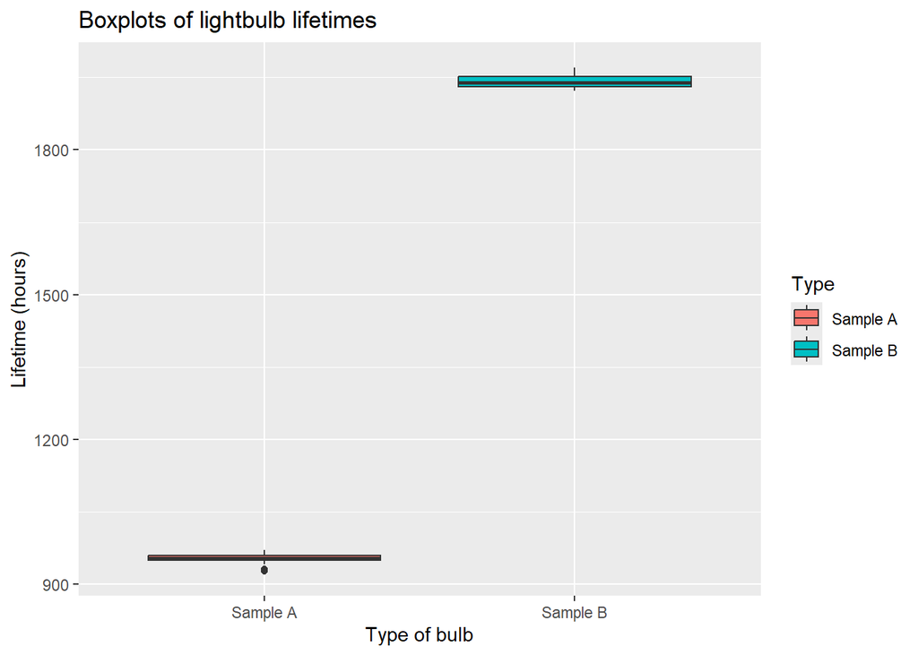

```r
ggplot(bulbs, aes(x = Type, y = Hours, fill = Type)) +
  geom_boxplot() +
  labs(title = "Boxplots of lightbulb lifetimes",
       x = "Type of bulb", y = "Lifetime (hours)")
```

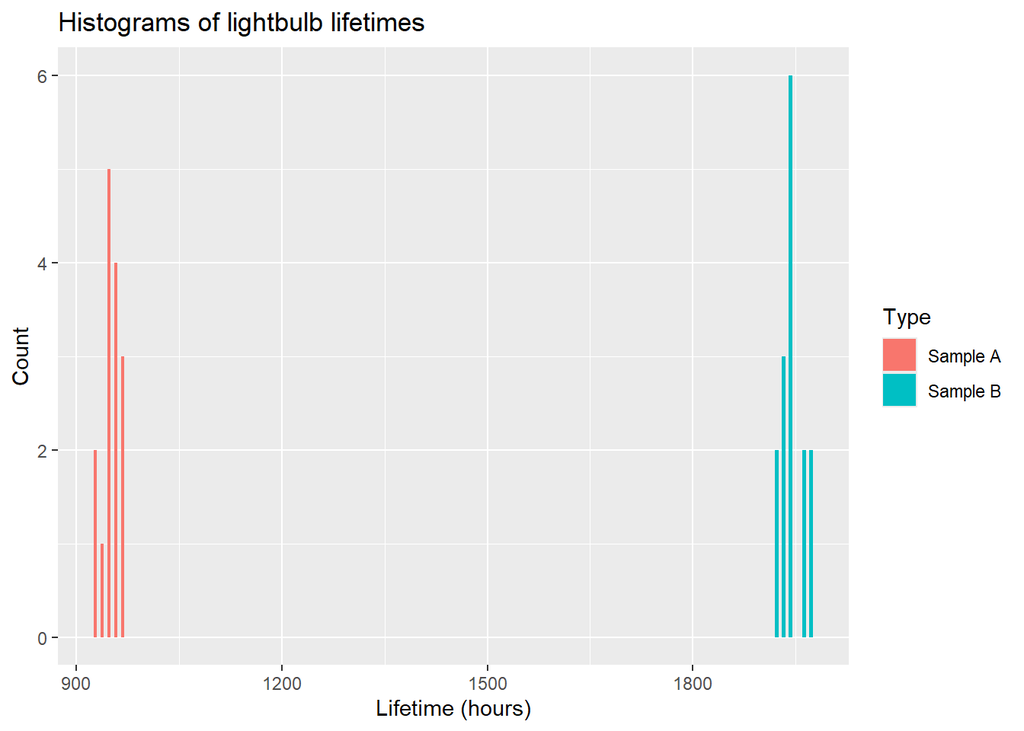

```r
ggplot(bulbs, aes(x = Hours, fill = Type)) +
  geom_histogram(position = "dodge", binwidth = 10) +
  labs(title = "Histograms of lightbulb lifetimes",
       x = "Lifetime (hours)", y = "Count")
```

**(b) Explain the differences in your own words and form a recommendation on the type of bulb the company should choose.**

The two distributions have almost no overlap: every Type B bulb outlasted every Type A bulb. Sample B averages about 1942 hours (median 1939) against about 953 hours (median 954) for Sample A, so Type B bulbs last roughly 2.04 times longer. The spreads are fairly similar in absolute terms (SD of about 15.7 hours for B versus 12.3 hours for A), and both distributions are unimodal and roughly symmetric, so the shapes are alike — B is essentially the same kind of distribution shifted up to about twice the lifetime. Because Type B costs exactly twice the price of Type A, the cost per hour of light is almost identical for the two types (A: 1/953 ≈ 0.00105 per hour; B: 2/1942 ≈ 0.00103 per hour), with B marginally cheaper per hour of light. I recommend the company choose **Sample B**: for essentially the same cost per hour of light it needs to be replaced only half as often, which means less maintenance labour and disruption, and it is slightly more consistent relative to its mean lifetime.

## Question 4: General Social Survey

```r
GSS = read.csv("https://R-Resources.massey.ac.nz/data/GSS/GSS26118.csv")
GSS |> head()
```

```
  ID Surfweight Year   Age    Sex      Ethnicity Edu                     LFS
1  1   3238.951 2021 15-24 Female European/Other   1 Not in the labour force
2  2   6468.014 2021 55-64   Male          Maori   3                Employed
3  3   4822.019 2021 25-34   Male European/Other   3                Employed
4  4   4549.766 2021 55-64 Female European/Other   1                Employed
5  5   3157.550 2021 45-54   Male European/Other   3                Employed
6  6   2717.784 2021 15-24   Male European/Other   1 Not in the labour force
  Partner Parent NumberChildren Tenure HhIncome NZDep Migrant   Disability
1       0      0              0      3        3     6       5 not disabled
2       1      0              0      1        3     1       6 not disabled
3       0      1              2      3        1     8       1 not disabled
4       1      0              0      1        3     4       1 not disabled
5       1      1              1      2        3     5       2     Disabled
6       0      0              0      1        3     3       1 not disabled
  HomeAfford LifeSatisfy LifeWorth Health TeReo GovTereo Selfactual Trust
```

[output cut: 27 more lines]

**(a) Choose any two demographic variables. Are these two variables independent of one another or associated somehow?**

I chose **Age** (age group) and **Edu** (highest completed qualification). Per the codebook, Edu is coded: 1 = less than secondary school completion/NCEA L4, 2 = secondary school completion/NCEA L4, 3 = post-secondary school NCEA or diploma, 4 = Bachelor’s degree or higher. To check for independence I compare the distribution of education within each age group: if Age and Edu are independent, the education distribution should be roughly the same for every age group.

```r
# Counts for every Age x Edu combination
age_edu = GSS |> group_by(Age, Edu) |>
  summarise(n = n(), .groups = "drop")
age_edu |> pivot_wider(names_from = Edu, values_from = n)
```

```
# A tibble: 6 × 5
  Age     `1`   `2`   `3`   `4`
  <chr> <int> <int> <int> <int>
1 15-24   133    23    10    11
2 25-34   103    58    39   110
3 35-44    77    68    52   122
4 45-54   115    61    50   108
5 55-64   111    62    54    68
6 65+     251   122    76    73
```

```r
# Distribution of education within each age group (proportions)
age_edu |> group_by(Age) |>
  mutate(Prop = round(n / sum(n), 3)) |>
  select(Age, Edu, Prop) |>
  pivot_wider(names_from = Edu, values_from = Prop)
```

```
# A tibble: 6 × 5
# Groups:   Age [6]
  Age     `1`   `2`   `3`   `4`
  <chr> <dbl> <dbl> <dbl> <dbl>
1 15-24 0.751 0.13  0.056 0.062
2 25-34 0.332 0.187 0.126 0.355
3 35-44 0.241 0.213 0.163 0.382
4 45-54 0.344 0.183 0.15  0.323
5 55-64 0.376 0.21  0.183 0.231
6 65+   0.481 0.234 0.146 0.14
```

Age and education are **associated**, not independent. The education distribution changes markedly with age: 75.1% of 15–24 year-olds have not completed secondary school (Edu = 1) compared with 24.1%–48.1% for the older age groups, while only 6.2% of the youngest group have a Bachelor’s degree or higher (Edu = 4) compared with 32.3%–38.2% of 25–54 year-olds. If the two variables were independent, the education proportions would be about the same in every age group, and they clearly are not.

**(b) Use the same approach to see if voting at the last general election is linked to ethnicity. N.B. You need to remove the people who were not eligible to vote.**

I remove the people who were not eligible to vote, then compare the voting distribution within each ethnic group.

```r
GSS_voters = GSS |> filter(Voted != "Not Eligible")

# Counts of voters and non-voters for each ethnic group
vote_eth = GSS_voters |> group_by(Ethnicity, Voted) |>
  summarise(n = n(), .groups = "drop")
vote_eth |> pivot_wider(names_from = Voted, values_from = n)
```

```
# A tibble: 4 × 3
  Ethnicity         No   Yes
  <chr>          <int> <int>
1 Asian             28   177
2 European/Other   211  1127
3 Maori             52   202
4 Pacific            9    86
```

```r
# Turnout (proportion who voted) within each ethnic group
GSS_voters |> group_by(Ethnicity) |>
  summarise(n = n(), n_voted = sum(Voted == "Yes"),
            Turnout = round(n_voted / n, 3), .groups = "drop")
```

```
# A tibble: 4 × 4
  Ethnicity          n n_voted Turnout
  <chr>          <int>   <int>   <dbl>
1 Asian            205     177   0.863
2 European/Other  1338    1127   0.842
3 Maori            254     202   0.795
4 Pacific           95      86   0.905
```

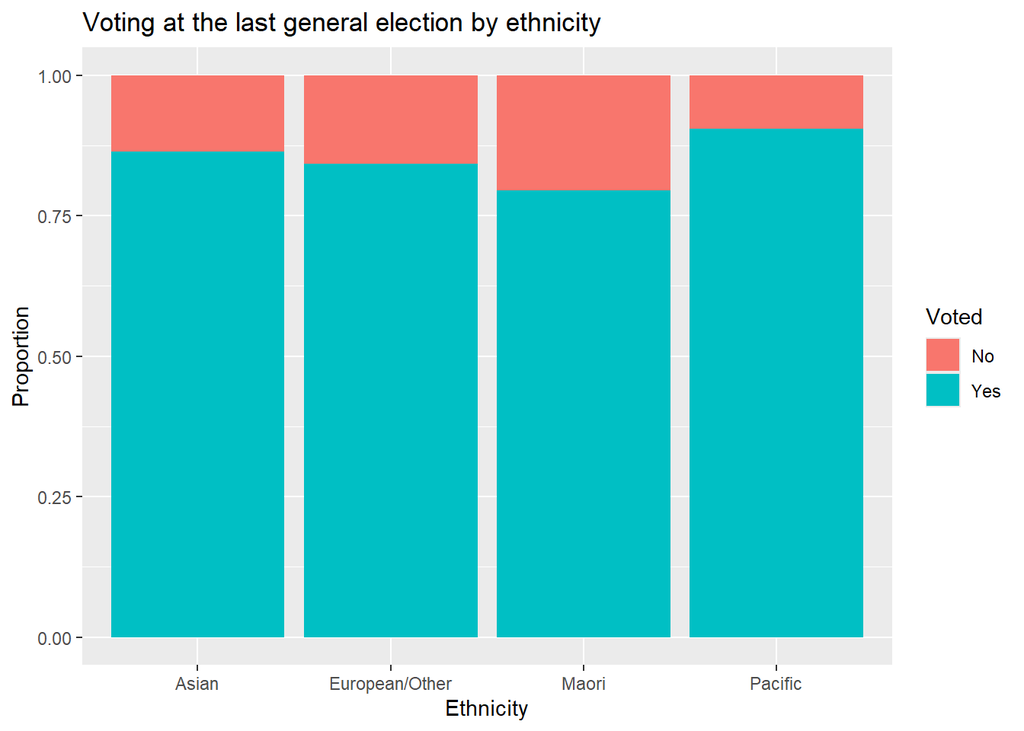

```r
ggplot(GSS_voters, aes(x = Ethnicity, fill = Voted)) +
  geom_bar(position = "fill") +
  labs(title = "Voting at the last general election by ethnicity",
       x = "Ethnicity", y = "Proportion")
```

Voting is **linked** to ethnicity. After removing the 65 people who were not eligible, turnout was 0.905 for Pacific, 0.863 for Asian, 0.842 for European/Other and only 0.795 for Māori, a spread of about 11 percentage points. If voting were independent of ethnicity, the turnout proportions would be roughly equal across all ethnic groups, and they are not.

**(c) Find the proportion of people who are deemed disabled for each gender and ethnicity combination. Tabulate these proportions, the number of survey respondents in each combined group, and the associated standard error for this proportion. Present a graph which displays the proportions and their associated standard errors.**

For each Sex × Ethnicity combination I calculate the number of respondents (n), the number and proportion deemed disabled, and the standard error of the proportion, SE = √(p(1−p)/n).

```r
disab = GSS |>
  group_by(Sex, Ethnicity) |>
  summarise(n = n(),
            n_disabled = sum(Disability == "Disabled"),
            Prop = mean(Disability == "Disabled"),
            SE = sqrt(Prop * (1 - Prop) / n),
            .groups = "drop") |>
  mutate(Prop = round(Prop, 3), SE = round(SE, 3))
disab
```

```
# A tibble: 9 × 6
  Sex            Ethnicity          n n_disabled  Prop    SE
  <chr>          <chr>          <int>      <int> <dbl> <dbl>
1 Female         Asian             92         14 0.152 0.037
2 Female         European/Other   644         66 0.102 0.012
3 Female         Maori            110          8 0.073 0.025
4 Female         Pacific           42          7 0.167 0.058
5 Gender Diverse European/Other     2          0 0     0
6 Male           Asian            120         19 0.158 0.033
7 Male           European/Other   740         83 0.112 0.012
8 Male           Maori            152         12 0.079 0.022
9 Male           Pacific           55          3 0.055 0.031
```

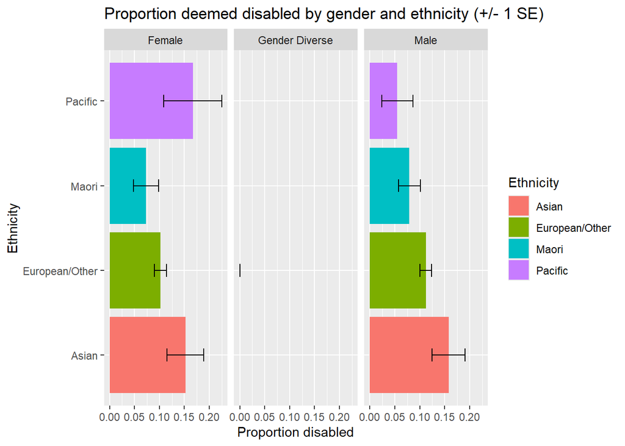

```r
ggplot(disab, aes(x = Prop, y = Ethnicity, fill = Ethnicity)) +
  geom_col() +
  geom_errorbar(aes(xmin = Prop - SE, xmax = Prop + SE), width = 0.15) +
  facet_wrap(vars(Sex)) +
  labs(title = "Proportion deemed disabled by gender and ethnicity (+/- 1 SE)",
       x = "Proportion disabled", y = "Ethnicity")
```

The proportion of people deemed disabled varies across the gender and ethnicity combinations, from 0.055 (Pacific males) up to 0.167 (Pacific females) among the well-sampled groups, with Asian respondents (0.152 for females, 0.158 for males) also above the other groups. The error bars show how much uncertainty there is in each estimate: the large European/Other groups have very small standard errors (about 0.012), while small groups such as Pacific females (n = 42) have standard errors around 0.058. The Gender Diverse combination is based on only n = 2 respondents, so its estimate (0.000) is too small a sample to be reliable and its standard error of 0 should not be taken at face value.

## Question 5: Evaluation of Digital Scales

```r
Scales = read.csv("https://R-Resources.massey.ac.nz/data/scales/scales26118.csv") |> glimpse()
```

```
Rows: 25
Columns: 4
$ A50  <dbl> 49.75, 50.35, 49.80, 49.87, 50.70, 50.60, 49.38, 49.40, 49.72, 49…
$ A100 <dbl> 99.86, 99.55, 99.98, 100.24, 100.25, 99.33, 100.45, 99.94, 100.03…
$ B50  <dbl> 50.16, 51.36, 50.42, 49.25, 50.22, 50.70, 50.52, 50.29, 50.66, 49…
$ B100 <dbl> 99.88, 99.86, 101.14, 99.66, 101.35, 100.45, 100.12, 98.86, 99.62…
```

**(a) Accuracy is a measure of biasedness and is calculated as the average of the sampled readings of an instrument minus the target reading that should have been seen. Contrast this with precision, which measures how consistent an instrument is in its readings. Precision is measured by the standard deviation of the readings. What is the accuracy and precision of each brand?**

Each brand was tested with a 50g and a 100g benchmark weight on 25 sets of scales. Accuracy = average reading − target reading (measures bias), while precision = standard deviation of the readings (measures consistency).

```r
scale_summary = data.frame(
  Brand = c("A", "A", "B", "B"),
  Target = c(50, 100, 50, 100),
  Mean_reading = round(c(mean(Scales$A50), mean(Scales$A100),
                         mean(Scales$B50), mean(Scales$B100)), 2),
  Accuracy = round(c(mean(Scales$A50) - 50, mean(Scales$A100) - 100,
                     mean(Scales$B50) - 50, mean(Scales$B100) - 100), 2),
  Precision_SD = round(c(sd(Scales$A50), sd(Scales$A100),
                         sd(Scales$B50), sd(Scales$B100)), 2)
)
scale_summary
```

```
  Brand Target Mean_reading Accuracy Precision_SD
1     A     50        49.86    -0.14         0.42
2     A    100       100.04     0.04         0.41
3     B     50        50.22     0.22         0.61
4     B    100       100.30     0.30         0.72
```

**Brand A** has accuracy of −0.14g at the 50g target (it under-reads on average) and +0.04g at the 100g target, and its precision is a standard deviation of about 0.42g (50g) and 0.41g (100g). **Brand B** has accuracy of +0.22g at 50g and +0.30g at 100g (it consistently over-reads), and its precision is a standard deviation of about 0.61g (50g) and 0.72g (100g). So Brand A is both more accurate (its average readings sit much closer to the true targets) and more precise (its standard deviations are clearly smaller than Brand B’s at both weights) at both benchmark weights.

**(b) Form a recommendation on which brand should be purchased.**

I recommend the university purchase **Brand A**. Brand A’s readings are closer to the true weights (biases of only −0.14g and +0.04g compared with +0.22g and +0.30g for Brand B) and its readings are more consistent (standard deviations of about 0.41–0.42g compared with 0.61–0.72g for Brand B), so it is the better instrument on both criteria. Since Brand A is also the slightly cheaper of the two brands, there is no trade-off to consider: Brand A is more accurate, more precise, and cheaper.